# [COBA2] Analisis Pengaruh Sales dan Marketing terhadap Profit pada Coffee Chain Dataset

Alyssa Divania - M0725059 Statistika (A)

2026-04-13

# Pendahuluan

Profit merupakan indikator penting dalam menilai kinerja perusahaan. Dalam industri coffee chain, **profit** diduga dipengaruhi oleh tingkat penjualan **(Sales)** dan aktivitas pemasaran **(Marketing)**.

Semakin tinggi penjualan dan strategi pemasaran yang efektif, maka profit perusahaan berpotensi meningkat.

Penelitian ini bertujuan menganalisis pengaruh Sales dan Marketing terhadap Profit menggunakan *Regresi Linear Berganda*.

# Import Data

```r
library(readxl)
```

```r
library(ggplot2)
data_coffee_chain <- read_excel("C:/Users/Pongo/OneDrive/Documents/1. Tugas SIM 2025B - Coffee Chain Datasets.xlsx")

head(data_coffee_chain)
```

```
## # A tibble: 6 × 20
##   `Area Code` Date                Market  `Market Size` Product   `Product Line`
##         <dbl> <dttm>              <chr>   <chr>         <chr>     <chr>
## 1         719 2012-01-01 00:00:00 Central Major Market  Amaretto  Beans
## 2         970 2012-01-01 00:00:00 Central Major Market  Colombian Beans
## 3         970 2012-01-01 00:00:00 Central Major Market  Decaf Ir… Beans
## 4         303 2012-01-01 00:00:00 Central Major Market  Green Tea Leaves
## 5         303 2012-01-01 00:00:00 Central Major Market  Caffe Mo… Beans
## 6         720 2012-01-01 00:00:00 Central Major Market  Decaf Es… Beans
## # ℹ 14 more variables: `Product Type` <chr>, State <chr>, Type <chr>,
## #   `Budget COGS` <dbl>, `Budget Margin` <dbl>, `Budget Profit` <dbl>,
## #   `Budget Sales` <dbl>, COGS <dbl>, Inventory <dbl>, Margin <dbl>,
## #   Marketing <dbl>, Profit <dbl>, Sales <dbl>, `Total Expenses` <dbl>
```

```r
tail(data_coffee_chain)
```

```
## # A tibble: 6 × 20
##   `Area Code` Date                Market `Market Size` Product    `Product Line`
##         <dbl> <dttm>              <chr>  <chr>         <chr>      <chr>
## 1         425 2013-12-01 00:00:00 West   Small Market  Lemon      Leaves
## 2         206 2013-12-01 00:00:00 West   Small Market  Caffe Lat… Beans
## 3         509 2013-12-01 00:00:00 West   Small Market  Caffe Moc… Beans
## 4         360 2013-12-01 00:00:00 West   Small Market  Decaf Esp… Beans
## 5         360 2013-12-01 00:00:00 West   Small Market  Colombian  Beans
## 6         206 2013-12-01 00:00:00 West   Small Market  Decaf Iri… Beans
## # ℹ 14 more variables: `Product Type` <chr>, State <chr>, Type <chr>,
## #   `Budget COGS` <dbl>, `Budget Margin` <dbl>, `Budget Profit` <dbl>,
## #   `Budget Sales` <dbl>, COGS <dbl>, Inventory <dbl>, Margin <dbl>,
## #   Marketing <dbl>, Profit <dbl>, Sales <dbl>, `Total Expenses` <dbl>
```

```r
str(data_coffee_chain)
```

```
## tibble [4,248 × 20] (S3: tbl_df/tbl/data.frame)
##  $ Area Code     : num [1:4248] 719 970 970 303 303 720 970 719 970 719 ...
##  $ Date          : POSIXct[1:4248], format: "2012-01-01" "2012-01-01" ...
##  $ Market        : chr [1:4248] "Central" "Central" "Central" "Central" ...
##  $ Market Size   : chr [1:4248] "Major Market" "Major Market" "Major Market" "Major Market" ...
##  $ Product       : chr [1:4248] "Amaretto" "Colombian" "Decaf Irish Cream" "Green Tea" ...
##  $ Product Line  : chr [1:4248] "Beans" "Beans" "Beans" "Leaves" ...
##  $ Product Type  : chr [1:4248] "Coffee" "Coffee" "Coffee" "Tea" ...
##  $ State         : chr [1:4248] "Colorado" "Colorado" "Colorado" "Colorado" ...
##  $ Type          : chr [1:4248] "Regular" "Regular" "Decaf" "Regular" ...
##  $ Budget COGS   : num [1:4248] 90 80 100 30 60 80 140 50 50 40 ...
##  $ Budget Margin : num [1:4248] 130 110 140 50 90 130 160 80 70 70 ...
##  $ Budget Profit : num [1:4248] 100 80 110 30 70 80 110 20 40 20 ...
##  $ Budget Sales  : num [1:4248] 220 190 240 80 150 210 300 130 120 110 ...
##  $ COGS          : num [1:4248] 89 83 95 44 54 72 170 63 60 58 ...
##  $ Inventory     : num [1:4248] 777 623 821 623 456 ...
##  $ Margin        : num [1:4248] 130 107 139 56 80 108 171 87 80 72 ...
##  $ Marketing     : num [1:4248] 24 27 26 14 15 23 47 57 19 22 ...
##  $ Profit        : num [1:4248] 94 68 101 30 54 53 99 0 33 17 ...
##  $ Sales         : num [1:4248] 219 190 234 100 134 180 341 150 140 130 ...
##  $ Total Expenses: num [1:4248] 36 39 38 26 26 55 72 87 47 55 ...
```

```r
dim(data_coffee_chain)
```

```
## [1] 4248   20
```

```r
names(data_coffee_chain)
```

```
##  [1] "Area Code"      "Date"           "Market"         "Market Size"
##  [5] "Product"        "Product Line"   "Product Type"   "State"
##  [9] "Type"           "Budget COGS"    "Budget Margin"  "Budget Profit"
## [13] "Budget Sales"   "COGS"           "Inventory"      "Margin"
## [17] "Marketing"      "Profit"         "Sales"          "Total Expenses"
```

```r
summary(data_coffee_chain)
```

```
##    Area Code          Date                        Market
##  Min.   :203.0   Min.   :2012-01-01 00:00:00   Length:4248
##  1st Qu.:417.0   1st Qu.:2012-06-23 12:00:00   Class :character
##  Median :573.0   Median :2012-12-16 12:00:00   Mode  :character
##  Mean   :582.3   Mean   :2012-12-15 22:00:00
##  3rd Qu.:772.0   3rd Qu.:2013-06-08 12:00:00
##  Max.   :985.0   Max.   :2013-12-01 00:00:00
##  Market Size          Product          Product Line       Product Type
##  Length:4248        Length:4248        Length:4248        Length:4248
##  Class :character   Class :character   Class :character   Class :character
##  Mode  :character   Mode  :character   Mode  :character   Mode  :character
##
##
##
##     State               Type            Budget COGS     Budget Margin
##  Length:4248        Length:4248        Min.   :  0.00   Min.   :-210.0
##  Class :character   Class :character   1st Qu.: 30.00   1st Qu.:  50.0
##  Mode  :character   Mode  :character   Median : 50.00   Median :  70.0
##                                        Mean   : 74.83   Mean   : 100.8
##                                        3rd Qu.: 90.00   3rd Qu.: 130.0
##                                        Max.   :450.00   Max.   : 690.0
##  Budget Profit      Budget Sales         COGS          Inventory
##  Min.   :-320.00   Min.   :   0.0   Min.   :  0.00   Min.   :-3534.0
##  1st Qu.:  20.00   1st Qu.:  80.0   1st Qu.: 43.00   1st Qu.:  432.0
##  Median :  40.00   Median : 130.0   Median : 60.00   Median :  619.0
##  Mean   :  60.91   Mean   : 175.6   Mean   : 84.43   Mean   :  749.4
##  3rd Qu.:  80.00   3rd Qu.: 210.0   3rd Qu.:100.00   3rd Qu.:  910.5
##  Max.   : 560.00   Max.   :1140.0   Max.   :364.00   Max.   : 8252.0
##      Margin          Marketing          Profit           Sales
##  Min.   :-302.00   Min.   :  0.00   Min.   :-638.0   Min.   : 17
##  1st Qu.:  52.75   1st Qu.: 13.00   1st Qu.:  17.0   1st Qu.:100
##  Median :  76.00   Median : 22.00   Median :  40.0   Median :138
##  Mean   : 104.29   Mean   : 31.19   Mean   :  61.1   Mean   :193
##  3rd Qu.: 132.00   3rd Qu.: 39.00   3rd Qu.:  92.0   3rd Qu.:230
##  Max.   : 613.00   Max.   :156.00   Max.   : 778.0   Max.   :912
##  Total Expenses
##  Min.   : 10.00
##  1st Qu.: 33.00
##  Median : 46.00
##  Mean   : 54.06
##  3rd Qu.: 65.00
##  Max.   :190.00
```

# Visualisasi Data

### Scatterplot Sales dan Profit

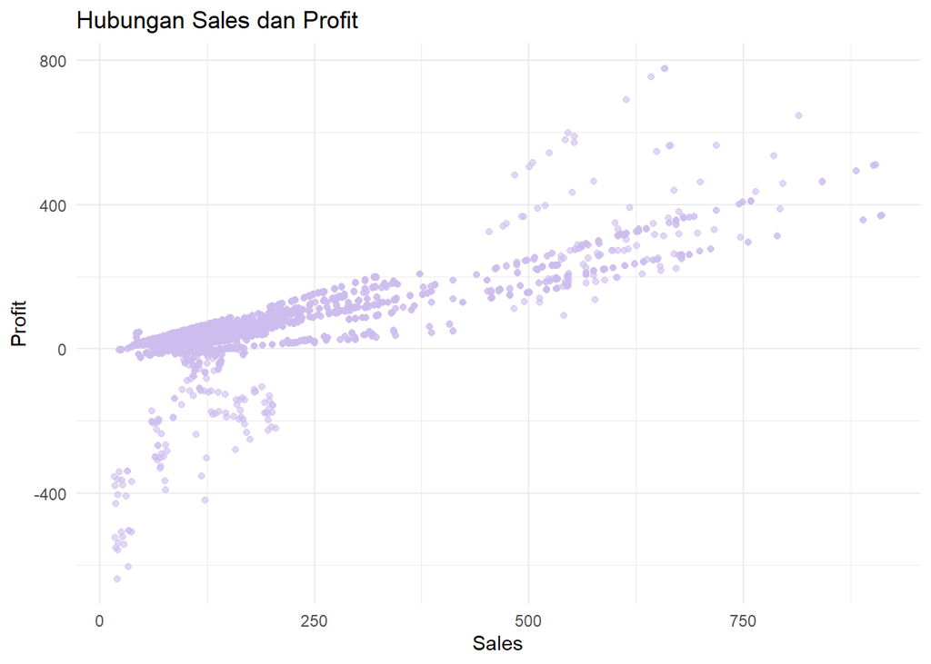

```r
ggplot(data_coffee_chain, aes(x = Sales, y = Profit)) +
  geom_point(color = "#CDBDEE", alpha = 0.6) +
  theme_minimal() +
  labs(
    title = "Hubungan Sales dan Profit",
    x = "Sales",
    y = "Profit"
  )
```

Interpretasi : Scatterplot menunjukkan adanya kecenderungan hubungan **positif** antara Sales dan Profit. Semakin tinggi nilai penjualan, maka profit cenderung meningkat. Namun terdapat *beberapa observasi dengan profit negatif*, yang menunjukkan adanya kerugian pada tingkat penjualan tertentu.

### Boxplot Marketing dan Profit

```r
data_coffee_chain$Kategori_Profit <- cut(
  data_coffee_chain$Profit,
  breaks = 3,
  labels = c("Rendah", "Sedang", "Tinggi")
)
```

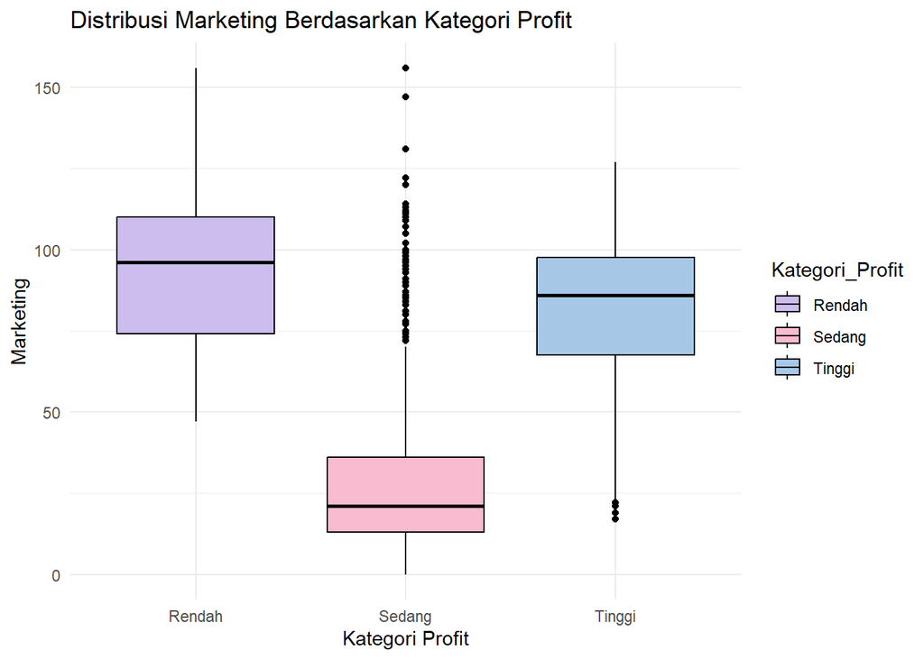

```r
ggplot(data_coffee_chain, aes(x = Kategori_Profit, y = Marketing, fill = Kategori_Profit)) +
  geom_boxplot(color = "black") +
  scale_fill_manual(values = c("#CDBDEE", "#F8BBD0", "#A7C7E7")) +
  theme_minimal() +
  labs(
    title = "Distribusi Marketing Berdasarkan Kategori Profit",
    x = "Kategori Profit",
    y  = "Marketing"
  )
```

# Analisis

Analisis Regresi Linear Berganda

```r
model <- lm(Profit ~ Sales + Marketing, data = data_coffee_chain)

summary(model)
```

```
##
## Call:
## lm(formula = Profit ~ Sales + Marketing, data = data_coffee_chain)
##
## Residuals:
##     Min      1Q  Median      3Q     Max
## -334.62  -13.59   -0.19   15.64  276.60
##
## Coefficients:
##               Estimate Std. Error t value Pr(>|t|)
## (Intercept) -25.172413   0.931639  -27.02   <2e-16 ***
## Sales         0.865916   0.005279  164.02   <2e-16 ***
## Marketing    -2.592300   0.029526  -87.80   <2e-16 ***
## ---
## Signif. codes:  0 '***' 0.001 '**' 0.01 '*' 0.05 '.' 0.1 ' ' 1
##
## Residual standard error: 36.59 on 4245 degrees of freedom
## Multiple R-squared:  0.8706, Adjusted R-squared:  0.8706
## F-statistic: 1.428e+04 on 2 and 4245 DF,  p-value: < 2.2e-16
```

# Hipotesis

### Uji Parsial

Untuk variabel Sales: - H0 : β1 = 0 (Sales tidak berpengaruh terhadap Profit) - H1 : β1 ≠ 0 (Sales berpengaruh terhadap Profit)

Untuk variabel Marketing: - H0 : β2 = 0 (Marketing tidak berpengaruh terhadap Profit) - H1 : β2 ≠ 0 (Marketing berpengaruh terhadap Profit)

### Uji Simultan

- H0 : β1 = β2 = 0
- H1 : minimal salah satu β ≠ 0

# Interpretasi Hasil Regresi

Berdasarkan hasil analisis regresi linear berganda, diperoleh persamaan:

Profit = -25.172 + 0.866(Sales) - 2.592(Marketing)

Artinya:

- setiap **kenaikan 1 unit Sales** akan **meningkatkan Profit** sebesar 0.866 unit, dengan asumsi variabel lain tetap.
- setiap **kenaikan 1 unit Marketing** akan **menurunkan Profit** sebesar 2.592 unit, dengan asumsi variabel lain tetap.

Nilai p-value pada variabel Sales dan Marketing **kurang dari 0.05**, sehingga kedua variabel berpengaruh signifikan terhadap Profit. Nilai R-squared sebesar 0.8706 menunjukkan bahwa 87.06% variasi Profit dapat dijelaskan oleh variabel Sales dan Marketing.

# Uji Normalitas Residual

```r
shapiro.test(residuals(model))
```

```
##
##  Shapiro-Wilk normality test
##
## data:  residuals(model)
## W = 0.82338, p-value < 2.2e-16
```

### Interpretasi Uji Normalitas

Berdasarkan uji Shapiro-Wilk diperoleh nilai statistik W sebesar 0.82338 dengan p-value < 0.05. Karena p-value lebih kecil dari taraf signifikan 5%, maka **H0 ditolak**.

Hal ini menunjukkan bahwa residual pada model regresi tidak berdistribusi normal.

Meskipun residual tidak normal berdasarkan uji statistik, jumlah sampel yang besar menyebabkan model regresi tetap dapat digunakan karena berdasarkan Teorema Limit Pusat, estimasi parameter tetap stabil.

# Kesimpulan

Berdasarkan hasil analisis regresi linear berganda, variabel Sales dan Marketing **berpengaruh signifikan** terhadap Profit pada Coffee Cahin Dataset.

Variabel Sales berpengaruh *positif* terhadap Profit, artinya peningkatan penjualan akan meningkatkan keuntungan perusahaan.

Variabel Marketing berpengaruh *negatif* terhadap Profit, yang menunjukkan bahwa peningkatan biaya pemasaran dapat menurunkan profit dalam jangka pendek.

Model memiliki nilai R-squared sebesar 87.06%, sehingga model mampu menjelaskan variasi Profit dengan baik.